# Assigment MP_6

## Decomposition (Additive)

##### Perform additive decomposition

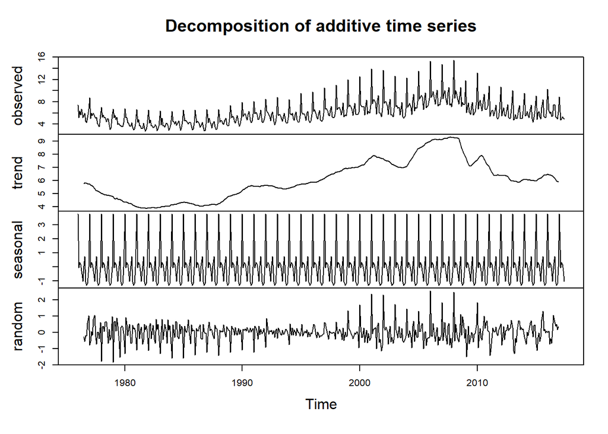

```r
add_decomp <- decompose(flightvolume_ts, type = "additive")
plot(add_decomp)
```

- Decomposition splits the time series into trend, seasonal, and residual components.

## Decomposition (Multiplicative)

##### Perform multiplicative decomposition

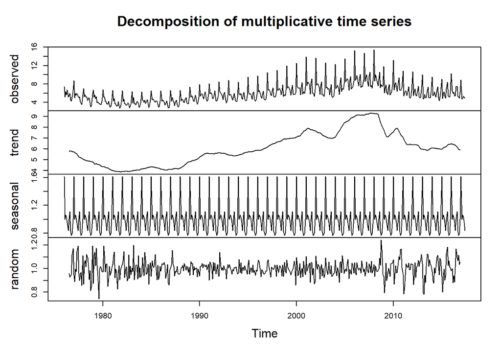

```r
mult_decomp <- decompose(flightvolume_ts, type = "multiplicative")
plot(mult_decomp)
```

- Multiplicative decomposition is used when the seasonal component changes proportionally to the trend.

## 8.Show model rank with accuracy measures (MAE and RMSE)

```r
naive_acc <- accuracy(naive_forecast)
naive_acc
```

```
##                        ME     RMSE     MAE       MPE     MAPE     MASE
## Training set -0.005070423 1.921782 1.27839 -3.431347 19.95608 2.617313
##                    ACF1
## Training set -0.3457839
```

```r
ses_acc <- accuracy(ses_forecast)
ses_acc
```

```
##                       ME     RMSE      MAE       MPE    MAPE     MASE      ACF1
## Training set 0.003102926 1.522827 1.029849 -4.540414 16.6577 2.108461 0.1289961
```

```r
hw_acc <- accuracy(hw_forecast)
hw_acc
```

```
##                       ME      RMSE       MAE        MPE     MAPE      MASE
## Training set 0.003339262 0.4280755 0.3159039 -0.1957689 5.329503 0.6467658
##                    ACF1
## Training set 0.08688442
```

```r
decomp_acc <- accuracy(decomp_forecast)
decomp_acc
```

```
##                        ME     RMSE       MAE      MPE     MAPE     MASE
## Training set -1.14411e-16 1.230212 0.9483529 -3.41291 15.68507 1.941611
##                   ACF1
## Training set 0.7763158
```

```r
# Create a summary of accuracy measures (MAE and RMSE)
accuracy_summary <- data.frame(
  Model = c("Naive","Exponential Smoothing", "Holt-Winters", "Decomposition"),
  MAE = c(naive_acc[1, "MAE"], ses_acc[1, "MAE"], hw_acc[1, "MAE"], decomp_acc[1, "MAE"]),
  RMSE = c(naive_acc[1, "RMSE"], ses_acc[1, "RMSE"], hw_acc[1, "RMSE"], decomp_acc[1, "RMSE"])
)

print(accuracy_summary)
```

```
##                   Model       MAE      RMSE
## 1                 Naive 1.2783903 1.9217818
## 2 Exponential Smoothing 1.0298487 1.5228266
## 3          Holt-Winters 0.3159039 0.4280755
## 4         Decomposition 0.9483529 1.2302119
```

- This table ranks the models based on their accuracy using MAE and RMSE. Lower values indicate better accuracy.

## 9.Choose which models to use for forecasting

- Based on the accuracy measures, we would select the model with the lowest MAE and RMSE, typically the Holt-Winters or Decomposition model.

##### Best & Worst Forecasts

- To start with, there is nothing like best or worst forecast.
- Considering the accuracy data above, HoltWinters forecast seems to fit the time series the best as it has the least error values.
- And naive forecast seems to be the worst as it has the largest ME and RMSE values.

## 10. Provide the forecast for the next 12 months (point and range)

```r
final_forecast <- forecast(hw_model, h=12)
print(final_forecast)
```

```
##          Point Forecast    Lo 80    Hi 80    Lo 95     Hi 95
## Jul 2017       6.677963 6.120331 7.235595 5.825138  7.530787
## Aug 2017       7.194588 6.595053 7.794123 6.277679  8.111497
## Sep 2017       4.762417 4.123700 5.401133 3.785584  5.739250
## Oct 2017       4.471027 3.795376 5.146679 3.437707  5.504347
## Nov 2017       4.444585 3.733895 5.155274 3.357679  5.531491
## Dec 2017       5.824163 5.080064 6.568262 4.686162  6.962164
## Jan 2018       8.907774 8.131685 9.683864 7.720847 10.094701
## Feb 2018       4.933483 4.126651 5.740314 3.699541  6.167424
## Mar 2018       5.120304 4.283843 5.956764 3.841048  6.399560
## Apr 2018       5.556597 4.691505 6.421689 4.233553  6.879642
## May 2018       5.072650 4.179827 5.965472 3.707196  6.438104
## Jun 2018       4.843105 3.923373 5.762838 3.436495  6.249715
```

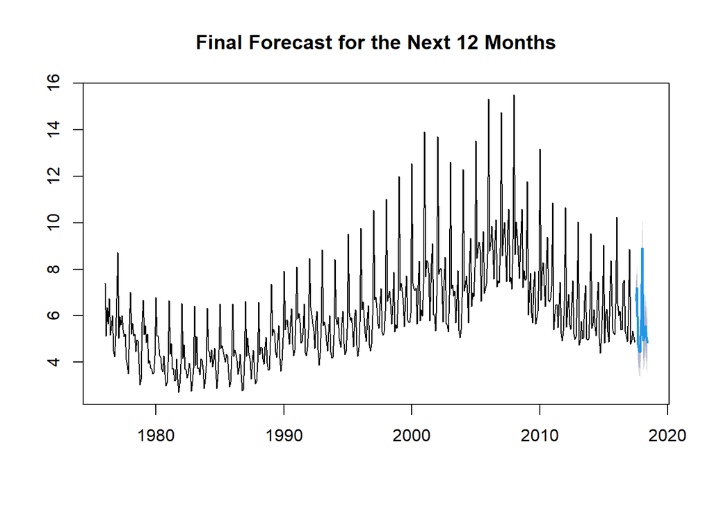

```r
plot(final_forecast, main="Final Forecast for the Next 12 Months")
```

- This is the final forecast, providing point estimates for the next 12 months along with confidence intervals.